# Day of the week

```
Rows: 252
Columns: 54
$ `Video ID`                <chr> "-2WiOnkthek", "-6_UhwQ_mgQ", "-DKfOVi3wyY",…
$ `Channel ID`              <chr> "UCpcsFse90FqtqZSbdzJMc0Q", "UCpcsFse90FqtqZ…
$ `Channel Name`            <chr> "Avaritia Hawthorne 【Variance Project】", "Av…
$ Title                     <chr> "jazz karaoke 🎶", "MONETIZATION BLOOD PARTY"…
$ `Published At`            <dttm> 2025-11-23 01:06:46, 2025-08-15 19:10:06, 2…
$ date                      <date> 2026-05-29, 2026-05-29, 2026-05-29, 2026-05…
$ `Content Type`            <chr> "live", "live", "live", "live", "live", "liv…
$ views                     <dbl> 496, 608, 1313, 520, 635, 526, 676, 10, 548,…
$ estimatedMinutesWatched   <dbl> 7460, 6744, 21924, 4369, 7689, 11271, 11424,…
$ averageViewDuration       <dbl> 902, 669, 1001, 504, 726, 1285, 1019, 46, 42…
$ averageViewPercentage     <dbl> 8.03, 5.78, 6.13, 13.13, 5.67, 12.35, 7.32, …
$ subscribersGained         <dbl> 5, 9, 18, 12, 3, 5, 7, 0, 0, 0, 4, 4, 1, 7, …
$ subscribersLost           <dbl> 2, 1, 1, 0, 0, 0, 0, 0, 0, 0, 0, 3, 0, 0, 1,…
```

[output cut: 41 more lines]

| Video ID | Channel ID | Channel Name | Title | Published At | date | Content Type | views | estimatedMinutesWatched | averageViewDuration | averageViewPercentage | subscribersGained | subscribersLost | DurationSeconds | DurationISO | publish_date | publish_year | publish_month | publish_month_num | publish_day | publish_wday | publish_wday_num | is_weekend | publish_hour | publish_min | publish_ampm | publish_hour_sin | publish_hour_cos | publish_week | publish_quarter | … |
| --- | --- | --- | --- | --- | --- | --- | --- | --- | --- | --- | --- | --- | --- | --- | --- | --- | --- | --- | --- | --- | --- | --- | --- | --- | --- | --- | --- | --- | --- | --- |
| -2WiOnkthek | UCpcsFse90FqtqZSbdzJMc0Q | Avaritia Hawthorne 【Variance Project】 | jazz karaoke 🎶 | 2025-11-23T01:06:46Z | 2026-05-29 | live | 496 | 7460 | 902 | 8.03 | 5 | 2 | 11243 | PT3H7M23S | 2025-11-23 | 2025 | Nov | 11 | 23 | Sun | 1 | True | 1 | 6 | AM | 0.2588190451025207 | 0.9659258262890683 | 47 | 4 | … |
| -6_UhwQ_mgQ | UCpcsFse90FqtqZSbdzJMc0Q | Avaritia Hawthorne 【Variance Project】 | MONETIZATION BLOOD PARTY | 2025-08-15T19:10:06Z | 2026-05-29 | live | 608 | 6744 | 669 | 5.78 | 9 | 1 | 11584 | PT3H13M4S | 2025-08-15 | 2025 | Aug | 8 | 15 | Fri | 6 | False | 19 | 10 | PM | -0.9659258262890684 | 0.2588190451025203 | 33 | 3 | … |
| -DKfOVi3wyY | UCpcsFse90FqtqZSbdzJMc0Q | Avaritia Hawthorne 【Variance Project】 | BONING【HANDCAM】 | 2026-01-17T03:02:00Z | 2026-05-29 | live | 1313 | 21924 | 1001 | 6.13 | 18 | 1 | 16337 | PT4H32M17S | 2026-01-17 | 2026 | Jan | 1 | 17 | Sat | 7 | True | 3 | 2 | AM | 0.7071067811865475 | 0.7071067811865476 | 3 | 1 | … |
| -E4SRtyDvb0 | UCpcsFse90FqtqZSbdzJMc0Q | Avaritia Hawthorne 【Variance Project】 | oh, there you are. i've been looking for you forever. 【 #GLEEKATHONRELAY 】 | 2026-01-31T23:23:13Z | 2026-05-29 | live | 520 | 4369 | 504 | 13.13 | 12 | 0 | 3841 | PT1H4M1S | 2026-01-31 | 2026 | Jan | 1 | 31 | Sat | 7 | True | 23 | 23 | PM | -0.2588190451025216 | 0.9659258262890681 | 5 | 1 | … |
| -PWgYLnfvXU | UCpcsFse90FqtqZSbdzJMc0Q | Avaritia Hawthorne 【Variance Project】 | DECAPITATION PRACTICE【HANDCAM】 | 2025-08-29T19:44:49Z | 2026-05-29 | live | 635 | 7689 | 726 | 5.67 | 3 | 0 | 12819 | PT3H33M39S | 2025-08-29 | 2025 | Aug | 8 | 29 | Fri | 6 | False | 19 | 44 | PM | -0.9659258262890684 | 0.2588190451025203 | 35 | 3 | … |
| -_4rTrDiZRY | UCpcsFse90FqtqZSbdzJMc0Q | Avaritia Hawthorne 【Variance Project】 | WE ALL WILL LIVE GUARANTEED 👍 | 2026-04-15T22:36:39Z | 2026-05-29 | live | 526 | 11271 | 1285 | 12.35 | 5 | 0 | 10421 | PT2H53M41S | 2026-04-15 | 2026 | Apr | 4 | 15 | Wed | 4 | False | 22 | 36 | PM | -0.5000000000000004 | 0.8660254037844384 | 16 | 2 | … |
| -upfZuJAOGg | UCpcsFse90FqtqZSbdzJMc0Q | Avaritia Hawthorne 【Variance Project】 | I WON'T SPIN THE PUNISHMENT WHEEL【ASK ME ANYTHING \| Variance Project】 | 2025-11-12T00:42:47Z | 2026-05-29 | live | 676 | 11424 | 1019 | 7.32 | 7 | 0 | 13937 | PT3H52M17S | 2025-11-12 | 2025 | Nov | 11 | 12 | Wed | 4 | False | 0 | 42 | AM | 0 | 1 | 46 | 4 | … |
| 02v1ASUwH5E | UCpcsFse90FqtqZSbdzJMc0Q | Avaritia Hawthorne 【Variance Project】 | Ava Hawthorne Performance 2026 | 2026-01-11T04:14:49Z | 2026-05-29 | video | 10 | 7 | 46 | 36.91 | 0 | 0 | 125 | PT2M5S | 2026-01-11 | 2026 | Jan | 1 | 11 | Sun | 1 | True | 4 | 14 | AM | 0.8660254037844386 | 0.5000000000000001 | 2 | 1 | … |
| 0Fg9OuJW_bg | UCpcsFse90FqtqZSbdzJMc0Q | Avaritia Hawthorne 【Variance Project】 | Everything’s Gnarly #vtuber | 2025-09-02T13:00:03Z | 2026-05-29 | short | 548 | 266 | 42 | 70.34 | 0 | 0 | 61 | PT1M1S | 2025-09-02 | 2025 | Sep | 9 | 2 | Tue | 3 | False | 13 | 0 | PM | -0.2588190451025208 | -0.9659258262890683 | 36 | 3 | … |
| 0Mu84BoKIBw | UCpcsFse90FqtqZSbdzJMc0Q | Avaritia Hawthorne 【Variance Project】 | Ava Hawthorne Debut Test 07/19 | 2025-07-19T15:50:25Z | 2026-05-29 | video | 3 | 18 | 364 | 39.94 | 0 | 0 | 912 | PT15M12S | 2025-07-19 | 2025 | Jul | 7 | 19 | Sat | 7 | True | 15 | 50 | PM | -0.7071067811865471 | -0.7071067811865479 | 29 | 3 | … |

[output cut: 15 more lines]

```
# A tibble: 3 × 1
  content_type
  <chr>
1 live
2 video
3 short
```

# Live Content

## Live Weekday Summary

This table describes live stream performance for each publish weekday. Use `n` to judge how much evidence there is for each day, compare `mean_views` and `median_views` for typical performance, and use the confidence interval columns as a rough guide to uncertainty around the mean.

| publish_wday | n | mean_views | median_views | sd_views | se_views | ci_low | ci_high | min_views | max_views |
| --- | --- | --- | --- | --- | --- | --- | --- | --- | --- |
| Monday | 18 | 989.3888888888889 | 814 | 587.6117304408023 | 138.5014130998177 | 697.1764499789663 | 1281.601327798812 | 218 | 2667 |
| Tuesday | 22 | 761.4090909090909 | 759.5 | 409.6811372264218 | 87.34431193405426 | 579.7666505528185 | 943.0515312653632 | 0 | 2143 |
| Wednesday | 24 | 633.3333333333334 | 600.5 | 206.6279299835222 | 42.17774958892987 | 546.0820106558447 | 720.5846560108221 | 325 | 1056 |
| Thursday | 11 | 1074.363636363636 | 782 | 692.6386175672379 | 208.8384008891813 | 609.0426815557665 | 1539.684591171506 | 408 | 2502 |
| Friday | 17 | 832.4117647058823 | 869 | 292.3882390810909 | 70.91456431880513 | 682.0796040144809 | 982.7439253972838 | 274 | 1508 |
| Saturday | 24 | 942.0416666666666 | 645 | 1475.902508833056 | 301.2673380612109 | 318.8226950156545 | 1565.260638317679 | 7 | 7756 |
| Sunday | 31 | 704.4193548387096 | 606 | 387.0164315369179 | 69.5102030755128 | 562.4605816656842 | 846.378128011735 | 160 | 2239 |

## Live Weekdays Ranked By Median Views

This is the same weekday summary, sorted by `median_views` from highest to lowest. Median views are useful when a few unusually large or unusually small streams might distort the mean.

| publish_wday | n | mean_views | median_views | sd_views | se_views | ci_low | ci_high | min_views | max_views |
| --- | --- | --- | --- | --- | --- | --- | --- | --- | --- |
| Friday | 17 | 832.4117647058823 | 869 | 292.3882390810909 | 70.91456431880513 | 682.0796040144809 | 982.7439253972838 | 274 | 1508 |
| Monday | 18 | 989.3888888888889 | 814 | 587.6117304408023 | 138.5014130998177 | 697.1764499789663 | 1281.601327798812 | 218 | 2667 |
| Thursday | 11 | 1074.363636363636 | 782 | 692.6386175672379 | 208.8384008891813 | 609.0426815557665 | 1539.684591171506 | 408 | 2502 |
| Tuesday | 22 | 761.4090909090909 | 759.5 | 409.6811372264218 | 87.34431193405426 | 579.7666505528185 | 943.0515312653632 | 0 | 2143 |
| Saturday | 24 | 942.0416666666666 | 645 | 1475.902508833056 | 301.2673380612109 | 318.8226950156545 | 1565.260638317679 | 7 | 7756 |
| Sunday | 31 | 704.4193548387096 | 606 | 387.0164315369179 | 69.5102030755128 | 562.4605816656842 | 846.378128011735 | 160 | 2239 |
| Wednesday | 24 | 633.3333333333334 | 600.5 | 206.6279299835222 | 42.17774958892987 | 546.0820106558447 | 720.5846560108221 | 325 | 1056 |

## Raw Views Model Fit

This table summarizes the linear model that predicts raw view counts from publish weekday. Higher R-squared values mean weekday explains more of the variation in views, while the model p-value tests whether the weekday model improves on a no-weekday baseline.

| metric | value |
| --- | --- |
| R-squared | 0.03934229997741527 |
| Adjusted R-squared | -0.00182874430926705 |
| Residual standard error | 712.8208756117937 |
| F-statistic | 0.9555817846996297 |
| Model p-value | 0.4577587526003082 |

## Raw Views Coefficients

This table shows how each weekday compares with the reference weekday, Monday. The intercept is the estimated Monday view count; each weekday coefficient is the estimated raw-view difference from Monday, with the p-value indicating whether that difference is clearly distinguishable from zero in this model.

| term | estimate | std_error | statistic | p_value |
| --- | --- | --- | --- | --- |
| (Intercept) | 989.3888888888889 | 168.0134916388106 | 5.888746666939352 | 2.754327653374203e-08 |
| publish_wdayTuesday | -227.9797979797976 | 226.5493459097101 | -1.006314086074023 | 0.3160006249172103 |
| publish_wdayWednesday | -356.0555555555555 | 222.2609578899613 | -1.601970759668166 | 0.1114160252586193 |
| publish_wdayThursday | 84.97474747474745 | 272.8015375535313 | 0.3114892541911463 | 0.755892073980076 |
| publish_wdayFriday | -156.9771241830069 | 241.0758567514123 | -0.6511524061278163 | 0.516015475669861 |
| publish_wdaySaturday | -47.3472222222227 | 222.2609578899615 | -0.2130253674406627 | 0.8316170603894197 |
| publish_wdaySunday | -284.9695340501792 | 211.2327973725311 | -1.349078067396918 | 0.1794897975827994 |

## Raw Views ANOVA

This table tests the overall weekday term for the raw-views model. The weekday row asks whether publish weekday, as a group of categories, explains a meaningful amount of raw-view variation.

| term | df | sum_sq | mean_sq | f_value | p_value |
| --- | --- | --- | --- | --- | --- |
| publish_wday | 6 | 2913264.608368029 | 485544.1013946715 | 0.9555817846996298 | 0.4577587526003087 |
| Residuals | 140 | 71135904.09911498 | 508113.6007079642 |  |  |

## Log Views Model Fit

This table summarizes the model using log-transformed views, which reduces the influence of unusually large streams. Use this model when view counts are skewed and percentage-style differences are easier to interpret than raw count differences.

| metric | value |
| --- | --- |
| R-squared | 0.04447573210805148 |
| Adjusted R-squared | 0.003524692055539291 |
| Residual standard error | 0.8226349441457353 |
| F-statistic | 1.086070880031854 |
| Model p-value | 0.3737259619480578 |

## Log Views Coefficients

This table shows weekday differences on the log-view scale relative to Monday. Positive estimates suggest higher expected views than Monday; negative estimates suggest lower expected views, with p-values showing how strong the evidence is for each difference.

| term | estimate | std_error | statistic | p_value |
| --- | --- | --- | --- | --- |
| (Intercept) | 6.757161844248518 | 0.1938969158154888 | 34.84924871460356 | 7.186907925398273e-71 |
| publish_wdayTuesday | -0.4708422547961585 | 0.2614505479496984 | -1.800884559196816 | 0.07387362067416768 |
| publish_wdayWednesday | -0.3570507072574679 | 0.2565015096151048 | -1.392002362065014 | 0.1661290691596681 |
| publish_wdayThursday | 0.05387578188506258 | 0.3148281500813372 | 0.1711275877685764 | 0.8643705304454873 |
| publish_wdayFriday | -0.09768103796996026 | 0.2782149495599063 | -0.3510991703518334 | 0.7260417478013081 |
| publish_wdaySaturday | -0.3840893001767838 | 0.2565015096151051 | -1.497415359282412 | 0.136536427001703 |
| publish_wdaySunday | -0.3143430911197361 | 0.243774398889707 | -1.28948360677512 | 0.1993562644925341 |

## Log Views ANOVA

This table tests the overall weekday term for the log-views model. If the weekday p-value is small, weekday appears to explain differences in viewership after reducing the impact of extreme view counts.

| term | df | sum_sq | mean_sq | f_value | p_value |
| --- | --- | --- | --- | --- | --- |
| publish_wday | 6 | 4.409849084784108 | 0.734974847464018 | 1.086070880031853 | 0.3737259619480578 |
| Residuals | 140 | 94.741955186152 | 0.6767282513296571 |  |  |

## Approximate Percent Change From Monday

This table converts the log-model coefficients into approximate percent changes from the reference weekday. Positive values indicate higher expected views than Monday, and negative values indicate lower expected views than Monday.

| term | estimate | approx_percent_change_from_reference |
| --- | --- | --- |
| (Intercept) | 6.757161844248518 | 85919.73539418883 |
| publish_wdayTuesday | -0.4708422547961585 | -37.55239212514346 |
| publish_wdayWednesday | -0.3570507072574679 | -30.02629849099792 |
| publish_wdayThursday | 0.05387578188506258 | 5.535349999025541 |
| publish_wdayFriday | -0.09768103796996026 | -9.306186354653201 |
| publish_wdaySaturday | -0.3840893001767838 | -31.89293952615452 |
| publish_wdaySunday | -0.3143430911197361 | -26.97315634416002 |

## Raw Views By Weekday

This boxplot shows the distribution of live stream views for each publish weekday. Compare the median line and the spread within each box; wide boxes or long whiskers mean performance varies more on that day.

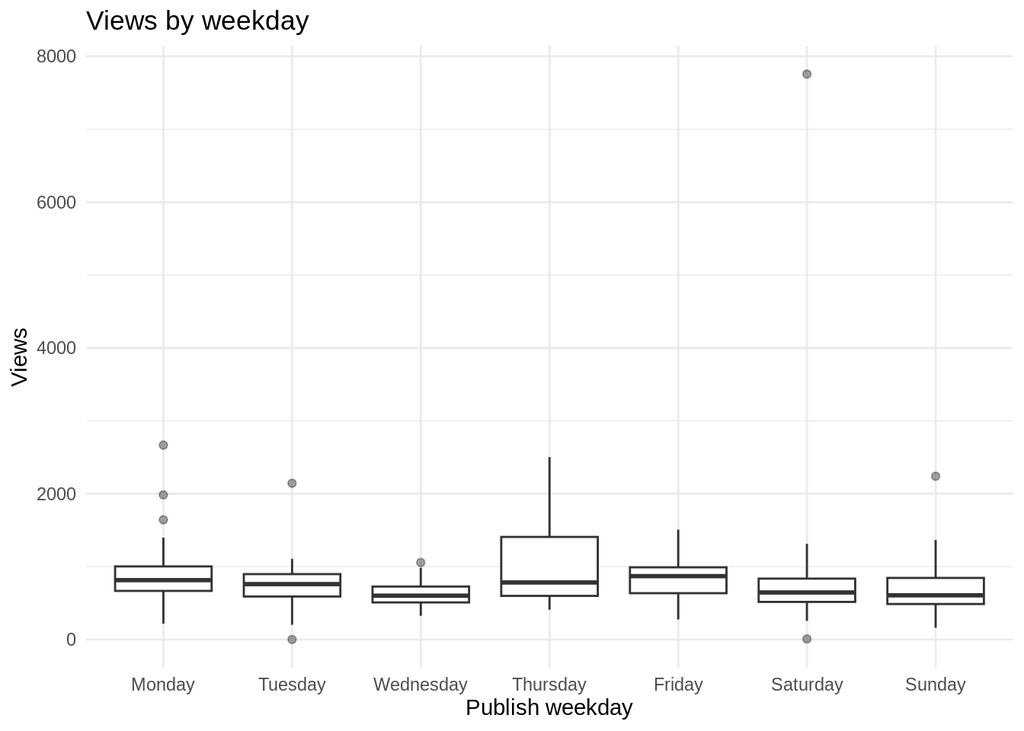

## Mean Views With Confidence Intervals

This plot compares average live stream views by publish weekday. The vertical bars show 95% confidence intervals; overlapping intervals suggest the weekday averages may not be clearly different.

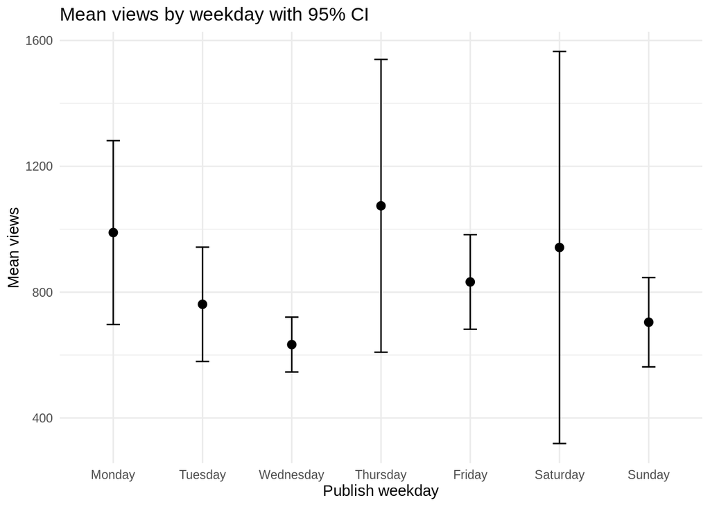

## Log Views By Weekday

This boxplot shows the same weekday pattern on a log scale, which makes extreme high-view streams less dominant. Use it to compare typical performance when raw views are heavily skewed.

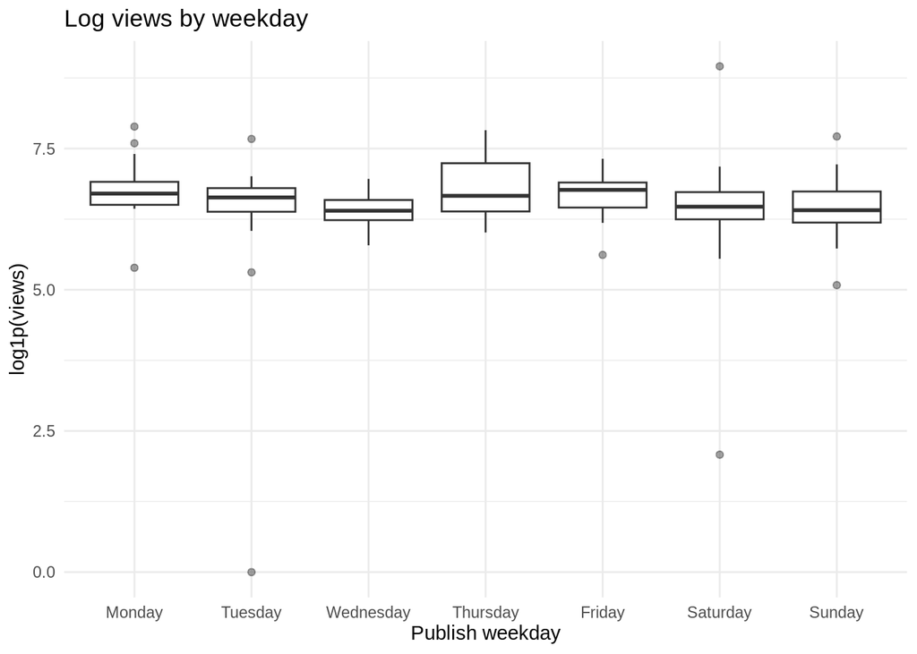

# Video Content

## Video Weekday Summary

This table describes video performance for each publish weekday. Use `n` to judge how many videos support each weekday estimate, compare `mean_views` and `median_views` for typical performance, and read the confidence interval columns as uncertainty around the mean.

| publish_wday | n | mean_views | median_views | sd_views | se_views | ci_low | ci_high | min_views | max_views |
| --- | --- | --- | --- | --- | --- | --- | --- | --- | --- |
| Monday | 4 | 1362.25 | 179.5 | 2437.568648605956 | 1218.784324302978 | -2516.465669815713 | 5240.965669815712 | 73 | 5017 |
| Tuesday | 3 | 1190.333333333333 | 1175 | 731.1206010866698 | 422.1126758474699 | -625.8709236636328 | 3006.537590330299 | 467 | 1929 |
| Wednesday | 7 | 1298.714285714286 | 738 | 1634.422804772959 | 617.7537540802743 | -212.8746962340322 | 2810.303267662604 | 224 | 4834 |
| Thursday | 1 | 122 | 122 |  |  |  |  | 122 | 122 |
| Friday | 7 | 2575.142857142857 | 885 | 3919.682743478586 | 1481.500822502245 | -1049.959062918906 | 6200.244777204621 | 329 | 11236 |
| Saturday | 4 | 409.75 | 375.5 | 362.4337870563394 | 181.2168935281697 | -166.9630332637148 | 986.4630332637148 | 3 | 885 |
| Sunday | 5 | 1009.8 | 379 | 1689.66289537292 | 755.6402186225929 | -1088.193586285289 | 3107.793586285288 | 10 | 4010 |

## Video Weekdays Ranked By Median Views

This is the same video weekday summary, sorted by `median_views` from highest to lowest. Median views are useful for ranking days when a small number of unusually strong or weak videos could pull the mean away from typical performance.

| publish_wday | n | mean_views | median_views | sd_views | se_views | ci_low | ci_high | min_views | max_views |
| --- | --- | --- | --- | --- | --- | --- | --- | --- | --- |
| Tuesday | 3 | 1190.333333333333 | 1175 | 731.1206010866698 | 422.1126758474699 | -625.8709236636328 | 3006.537590330299 | 467 | 1929 |
| Friday | 7 | 2575.142857142857 | 885 | 3919.682743478586 | 1481.500822502245 | -1049.959062918906 | 6200.244777204621 | 329 | 11236 |
| Wednesday | 7 | 1298.714285714286 | 738 | 1634.422804772959 | 617.7537540802743 | -212.8746962340322 | 2810.303267662604 | 224 | 4834 |
| Sunday | 5 | 1009.8 | 379 | 1689.66289537292 | 755.6402186225929 | -1088.193586285289 | 3107.793586285288 | 10 | 4010 |
| Saturday | 4 | 409.75 | 375.5 | 362.4337870563394 | 181.2168935281697 | -166.9630332637148 | 986.4630332637148 | 3 | 885 |
| Monday | 4 | 1362.25 | 179.5 | 2437.568648605956 | 1218.784324302978 | -2516.465669815713 | 5240.965669815712 | 73 | 5017 |
| Thursday | 1 | 122 | 122 |  |  |  |  | 122 | 122 |

## Video Raw Views Model Fit

This table summarizes the linear model that predicts raw video view counts from publish weekday. Higher R-squared values mean weekday explains more of the variation in views, while the model p-value tests whether the weekday model improves on a no-weekday baseline.

| metric | value |
| --- | --- |
| R-squared | 0.1043571832419203 |
| Adjusted R-squared | -0.1195535209475997 |
| Residual standard error | 2405.893105588001 |
| F-statistic | 0.4660660758477694 |
| Model p-value | 0.826463025745635 |

## Video Raw Views Coefficients

This table shows how each weekday compares with the reference weekday, Monday. The intercept is the estimated Monday view count; each weekday coefficient is the estimated raw-view difference from Monday, with the p-value indicating whether that difference is clearly distinguishable from zero in this model.

| term | estimate | std_error | statistic | p_value |
| --- | --- | --- | --- | --- |
| (Intercept) | 1362.25 | 1202.946552794 | 1.132427701659726 | 0.2686421613266802 |
| publish_wdayTuesday | -171.9166666666666 | 1837.531211721566 | -0.09355850152096165 | 0.9262365499831939 |
| publish_wdayWednesday | -63.53571428571408 | 1507.973308671924 | -0.04213318227871696 | 0.9667410984882511 |
| publish_wdayThursday | -1240.249999999999 | 2689.870265346424 | -0.4610817168315249 | 0.6488913034952513 |
| publish_wdayFriday | 1212.892857142858 | 1507.973308671924 | 0.8043198445011307 | 0.4291080458120899 |
| publish_wdaySaturday | -952.4999999999993 | 1701.223329771238 | -0.5598912167093789 | 0.580742376147157 |
| publish_wdaySunday | -352.4499999999993 | 1613.922159207854 | -0.2183810402435945 | 0.8289785279905533 |

## Video Raw Views ANOVA

This table tests the overall weekday term for the raw-views model. The weekday row asks whether publish weekday, as a group of categories, explains a meaningful amount of raw-view variation.

| term | df | sum_sq | mean_sq | f_value | p_value |
| --- | --- | --- | --- | --- | --- |
| publish_wday | 6 | 16186442.10245775 | 2697740.350409626 | 0.4660660758477692 | 0.8264630257456353 |
| Residuals | 24 | 138919719.252381 | 5788321.635515875 |  |  |

## Video Log Views Model Fit

This table summarizes the model using log-transformed views, which reduces the influence of unusually large videos. Use this model when view counts are skewed and percentage-style differences are easier to interpret than raw count differences.

| metric | value |
| --- | --- |
| R-squared | 0.2211909813355331 |
| Adjusted R-squared | 0.02648872666941626 |
| Residual standard error | 1.656139115013626 |
| F-statistic | 1.136047354535469 |
| Model p-value | 0.3719803436082105 |

## Video Log Views Coefficients

This table shows weekday differences on the log-view scale relative to Monday. Positive estimates suggest higher expected views than Monday; negative estimates suggest lower expected views, with p-values showing how strong the evidence is for each difference.

| term | estimate | std_error | statistic | p_value |
| --- | --- | --- | --- | --- |
| (Intercept) | 5.771048495055373 | 0.8280695575068128 | 6.969279866332839 | 3.311094548067063e-07 |
| publish_wdayTuesday | 1.156824073703011 | 1.264897142654519 | 0.9145597967557223 | 0.3695203195502137 |
| publish_wdayWednesday | 0.8413529923703227 | 1.03804012534369 | 0.8105206839588734 | 0.4256055933059896 |
| publish_wdayThursday | -0.9588641396829548 | 1.851619820683405 | -0.5178515205832332 | 0.6093028808501824 |
| publish_wdayFriday | 1.308168981618935 | 1.038040125343691 | 1.260229686386936 | 0.2197025987647101 |
| publish_wdaySaturday | -0.7627077241713461 | 1.171067198814422 | -0.6512928762273458 | 0.5210454807799278 |
| publish_wdaySunday | -0.228696406541718 | 1.110971892410042 | -0.2058525585607792 | 0.838642269804048 |

## Video Log Views ANOVA

This table tests the overall weekday term for the log-views model. If the weekday p-value is small, weekday appears to explain differences in viewership after reducing the impact of extreme view counts.

| term | df | sum_sq | mean_sq | f_value | p_value |
| --- | --- | --- | --- | --- | --- |
| publish_wday | 6 | 18.69568207578471 | 3.115947012630786 | 1.136047354535469 | 0.3719803436082105 |
| Residuals | 24 | 65.82712243867478 | 2.742796768278116 |  |  |

## Video Approximate Percent Change From Monday

This table converts the log-model coefficients into approximate percent changes from the reference weekday. Positive values indicate higher expected views than Monday, and negative values indicate lower expected views than Monday.

| term | estimate | approx_percent_change_from_reference |
| --- | --- | --- |
| (Intercept) | 5.771048495055373 | 31987.3991126969 |
| publish_wdayTuesday | 1.156824073703011 | 217.9818353764888 |
| publish_wdayWednesday | 0.8413529923703227 | 131.9503124741259 |
| publish_wdayThursday | -0.9588641396829548 | -61.6671954096369 |
| publish_wdayFriday | 1.308168981618935 | 269.9393848941054 |
| publish_wdaySaturday | -0.7627077241713461 | -53.35981718135863 |
| publish_wdaySunday | -0.228696406541718 | -20.44299732989264 |

## Video Raw Views By Weekday

This boxplot shows the distribution of video views for each publish weekday. Compare the median line and the spread within each box; wide boxes or long whiskers mean performance varies more on that day.

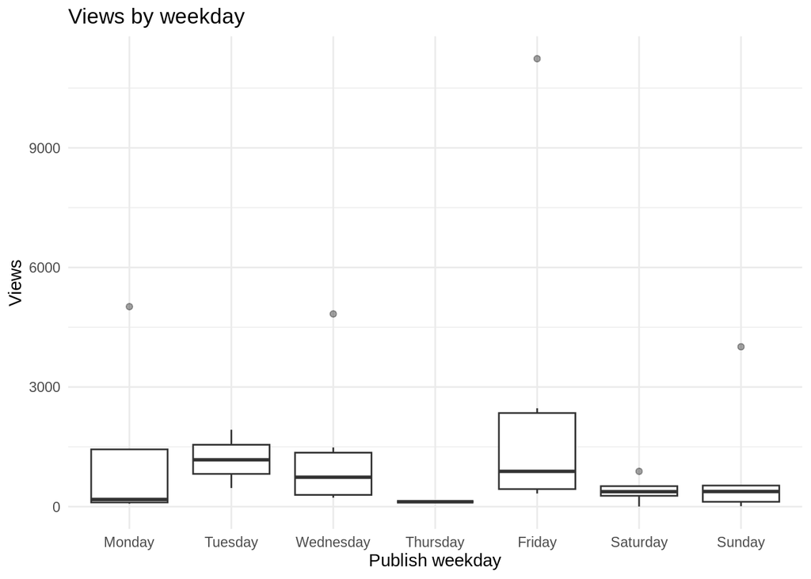

## Video Mean Views With Confidence Intervals

This plot compares average video views by publish weekday. The vertical bars show 95% confidence intervals; overlapping intervals suggest the weekday averages may not be clearly different.

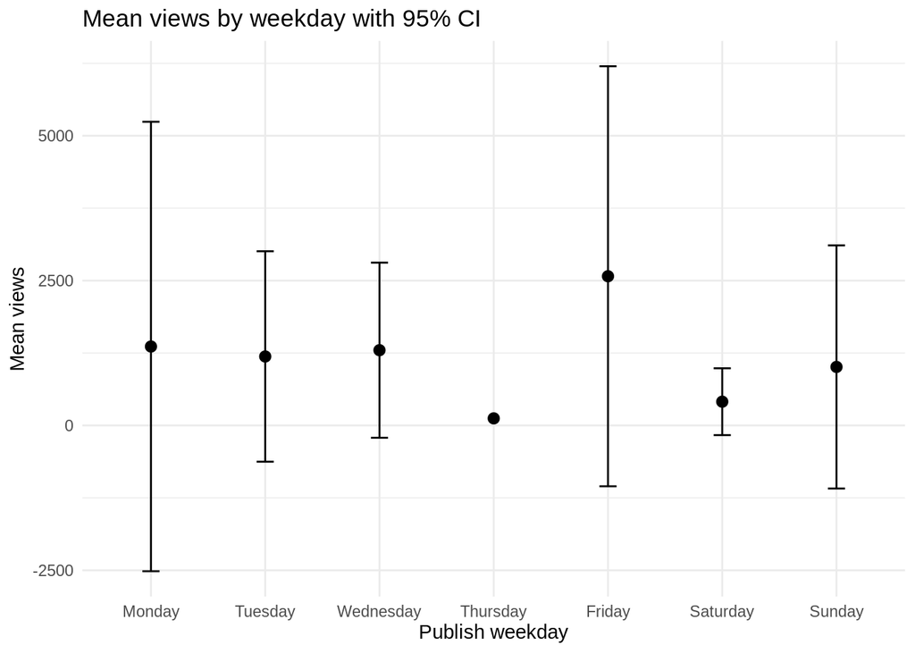

## Video Log Views By Weekday

This boxplot shows the same video weekday pattern on a log scale, which makes extreme high-view videos less dominant. Use it to compare typical performance when raw views are heavily skewed.

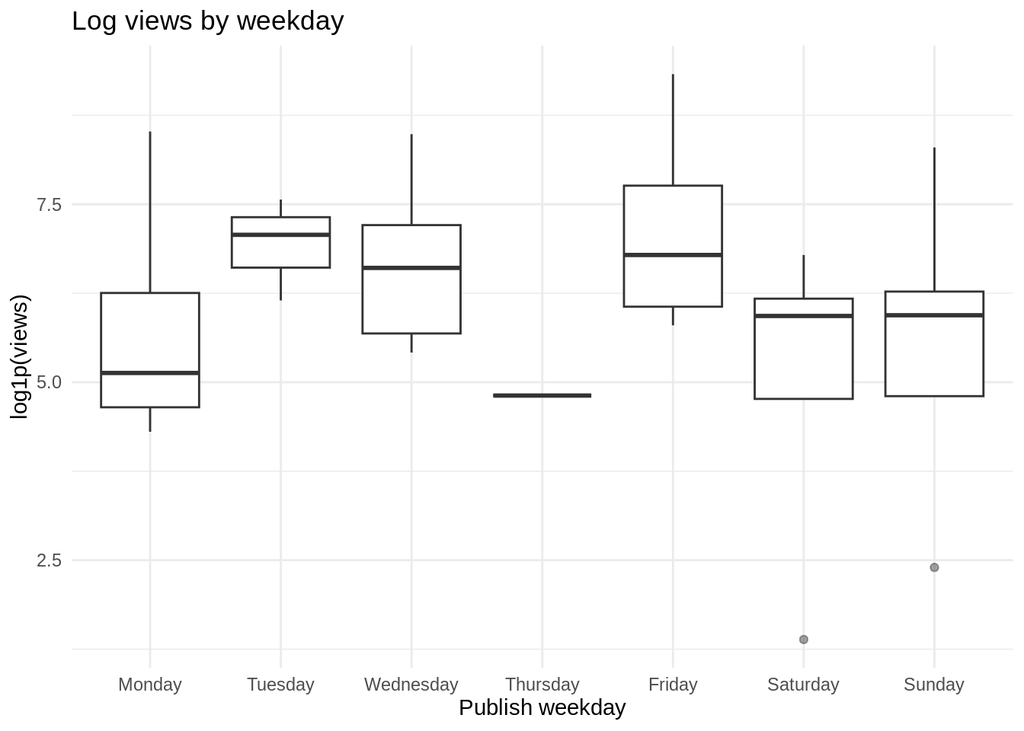

# Short Content

## Shorts Weekday Summary

This table describes Shorts performance for each publish weekday. Use `n` to judge how many Shorts support each weekday estimate, compare `mean_views` and `median_views` for typical performance, and read the confidence interval columns as uncertainty around the mean.

| publish_wday | n | mean_views | median_views | sd_views | se_views | ci_low | ci_high | min_views | max_views |
| --- | --- | --- | --- | --- | --- | --- | --- | --- | --- |
| Monday | 13 | 993.7692307692307 | 1004 | 747.447785673148 | 207.3047166905041 | 542.0910543934303 | 1445.447407145031 | 0 | 2148 |
| Tuesday | 12 | 850.25 | 565.5 | 589.6766640980616 | 170.2249903759282 | 475.58732230584 | 1224.91267769416 | 250 | 2099 |
| Wednesday | 12 | 1790.083333333333 | 1343 | 1999.875516959326 | 577.3143340311046 | 519.4230514226847 | 3060.743615243982 | 423 | 7923 |
| Thursday | 10 | 932.2 | 1044 | 491.5182374823723 | 155.4317141955842 | 580.5890344064558 | 1283.810965593544 | 0 | 1673 |
| Friday | 7 | 1257 | 1079 | 350.4159433206962 | 132.4447773512381 | 932.9193046769986 | 1581.080695323001 | 861 | 1736 |
| Saturday | 8 | 1025.125 | 998.5 | 661.1551444252702 | 233.7536430197399 | 472.3854668173607 | 1577.864533182639 | 0 | 2290 |
| Sunday | 12 | 2589 | 1100.5 | 5353.293124117833 | 1545.362613130202 | -812.3201784600105 | 5990.320178460011 | 246 | 19506 |

## Shorts Weekdays Ranked By Median Views

This is the same Shorts weekday summary, sorted by `median_views` from highest to lowest. Median views are useful for ranking days when a small number of unusually strong or weak Shorts could pull the mean away from typical performance.

| publish_wday | n | mean_views | median_views | sd_views | se_views | ci_low | ci_high | min_views | max_views |
| --- | --- | --- | --- | --- | --- | --- | --- | --- | --- |
| Wednesday | 12 | 1790.083333333333 | 1343 | 1999.875516959326 | 577.3143340311046 | 519.4230514226847 | 3060.743615243982 | 423 | 7923 |
| Sunday | 12 | 2589 | 1100.5 | 5353.293124117833 | 1545.362613130202 | -812.3201784600105 | 5990.320178460011 | 246 | 19506 |
| Friday | 7 | 1257 | 1079 | 350.4159433206962 | 132.4447773512381 | 932.9193046769986 | 1581.080695323001 | 861 | 1736 |
| Thursday | 10 | 932.2 | 1044 | 491.5182374823723 | 155.4317141955842 | 580.5890344064558 | 1283.810965593544 | 0 | 1673 |
| Monday | 13 | 993.7692307692307 | 1004 | 747.447785673148 | 207.3047166905041 | 542.0910543934303 | 1445.447407145031 | 0 | 2148 |
| Saturday | 8 | 1025.125 | 998.5 | 661.1551444252702 | 233.7536430197399 | 472.3854668173607 | 1577.864533182639 | 0 | 2290 |
| Tuesday | 12 | 850.25 | 565.5 | 589.6766640980616 | 170.2249903759282 | 475.58732230584 | 1224.91267769416 | 250 | 2099 |

## Shorts Raw Views Model Fit

This table summarizes the linear model that predicts raw Shorts view counts from publish weekday. Higher R-squared values mean weekday explains more of the variation in views, while the model p-value tests whether the weekday model improves on a no-weekday baseline.

| metric | value |
| --- | --- |
| R-squared | 0.06931529382301091 |
| Adjusted R-squared | -0.01402960523761498 |
| Residual standard error | 2368.101853236863 |
| F-statistic | 0.8316680997188597 |
| Model p-value | 0.5496816523846338 |

## Shorts Raw Views Coefficients

This table shows how each weekday compares with the reference weekday, Monday. The intercept is the estimated Monday view count; each weekday coefficient is the estimated raw-view difference from Monday, with the p-value indicating whether that difference is clearly distinguishable from zero in this model.

| term | estimate | std_error | statistic | p_value |
| --- | --- | --- | --- | --- |
| (Intercept) | 993.7692307692306 | 656.7932813359083 | 1.513062418586131 | 0.1349668827496703 |
| publish_wdayTuesday | -143.5192307692311 | 947.9994444530594 | -0.15139168235698 | 0.8801216681459889 |
| publish_wdayWednesday | 796.314102564103 | 947.9994444530598 | 0.8399942713294833 | 0.4038991223398801 |
| publish_wdayThursday | -61.56923076922993 | 996.0763289720213 | -0.06181175978026814 | 0.9508967625607374 |
| publish_wdayFriday | 263.2307692307702 | 1110.183272396293 | 0.237105688561309 | 0.8132982912561 |
| publish_wdaySaturday | 31.3557692307702 | 1064.126737198617 | 0.02946619808963386 | 0.9765803746420691 |
| publish_wdaySunday | 1595.230769230772 | 947.9994444530614 | 1.682733865051075 | 0.09708158107745286 |

## Shorts Raw Views ANOVA

This table tests the overall weekday term for the raw-views model. The weekday row asks whether publish weekday, as a group of categories, explains a meaningful amount of raw-view variation.

| term | df | sum_sq | mean_sq | f_value | p_value |
| --- | --- | --- | --- | --- | --- |
| publish_wday | 6 | 27983501.09118161 | 4663916.848530267 | 0.8316680997188605 | 0.549681652384633 |
| Residuals | 67 | 375729727.9493591 | 5607906.387303867 |  |  |

## Shorts Log Views Model Fit

This table summarizes the model using log-transformed views, which reduces the influence of unusually large Shorts. Use this model when view counts are skewed and percentage-style differences are easier to interpret than raw count differences.

| metric | value |
| --- | --- |
| R-squared | 0.1111240352608072 |
| Adjusted R-squared | 0.03152320259759578 |
| Residual standard error | 1.84950495371039 |
| F-statistic | 1.396015990573485 |
| Model p-value | 0.2291983235124775 |

## Shorts Log Views Coefficients

This table shows weekday differences on the log-view scale relative to Monday. Positive estimates suggest higher expected views than Monday; negative estimates suggest lower expected views, with p-values showing how strong the evidence is for each difference.

| term | estimate | std_error | statistic | p_value |
| --- | --- | --- | --- | --- |
| (Intercept) | 5.438429382312735 | 0.5129603803713433 | 10.60204567529316 | 5.692619274280405e-16 |
| publish_wdayTuesday | 1.110644432548461 | 0.7403945342275187 | 1.500071085353483 | 0.1382937757739085 |
| publish_wdayWednesday | 1.741875502510414 | 0.740394534227519 | 2.352631498458828 | 0.02158612620900792 |
| publish_wdayThursday | 0.7424373843565546 | 0.7779429344178413 | 0.9543596985197165 | 0.3433322705224816 |
| publish_wdayFriday | 1.665727110684364 | 0.867061295955998 | 1.921118055267107 | 0.05897283210633641 |
| publish_wdaySaturday | 0.6705121605159172 | 0.8310908034358359 | 0.8067856818339634 | 0.4226446694089653 |
| publish_wdaySunday | 1.611276307207365 | 0.7403945342275202 | 2.176240143221028 | 0.03306716055518713 |

## Shorts Log Views ANOVA

This table tests the overall weekday term for the log-views model. If the weekday p-value is small, weekday appears to explain differences in viewership after reducing the impact of extreme view counts.

| term | df | sum_sq | mean_sq | f_value | p_value |
| --- | --- | --- | --- | --- | --- |
| publish_wday | 6 | 28.65184816485589 | 4.775308027475981 | 1.396015990573485 | 0.2291983235124777 |
| Residuals | 67 | 229.1847944445513 | 3.420668573799273 |  |  |

## Shorts Approximate Percent Change From Monday

This table converts the log-model coefficients into approximate percent changes from the reference weekday. Positive values indicate higher expected views than Monday, and negative values indicate lower expected views than Monday.

| term | estimate | approx_percent_change_from_reference |
| --- | --- | --- |
| (Intercept) | 5.438429382312735 | 22908.05309746472 |
| publish_wdayTuesday | 1.110644432548461 | 203.6314463958483 |
| publish_wdayWednesday | 1.741875502510414 | 470.8038831061446 |
| publish_wdayThursday | 0.7424373843565546 | 110.1050345802448 |
| publish_wdayFriday | 1.665727110684364 | 428.9517916834589 |
| publish_wdaySaturday | 0.6705121605159172 | 95.523846018049 |
| publish_wdaySunday | 1.611276307207365 | 400.9200428284738 |

## Shorts Raw Views By Weekday

This boxplot shows the distribution of Shorts views for each publish weekday. Compare the median line and the spread within each box; wide boxes or long whiskers mean performance varies more on that day.

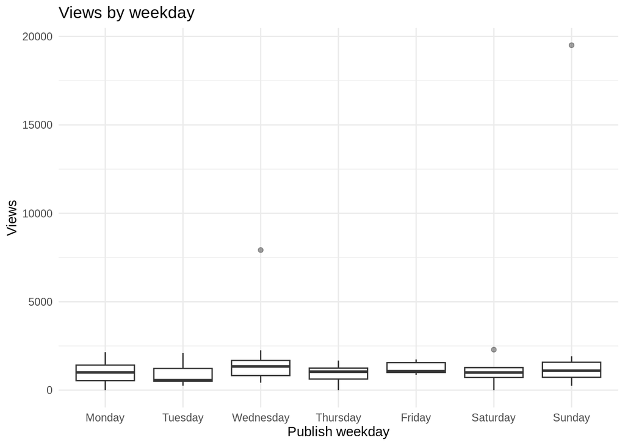

## Shorts Mean Views With Confidence Intervals

This plot compares average Shorts views by publish weekday. The vertical bars show 95% confidence intervals; overlapping intervals suggest the weekday averages may not be clearly different.

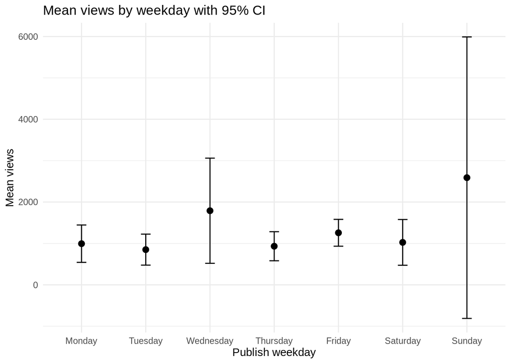

## Shorts Log Views By Weekday

This boxplot shows the same Shorts weekday pattern on a log scale, which makes extreme high-view Shorts less dominant. Use it to compare typical performance when raw views are heavily skewed.

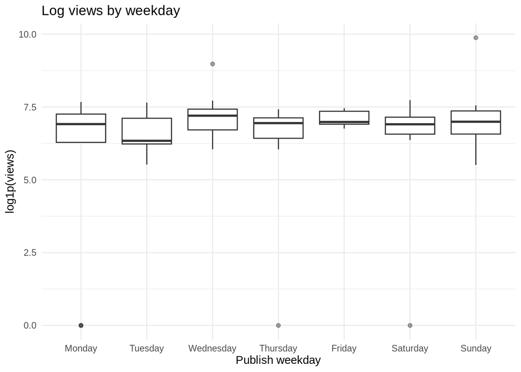